# ggplot2 Practice

### BYOPlot

Choose a built-in dataset of interest (e.g. `diamonds`, `mtcars`, `CO2`, `quakes`) and construct plots using the following geoms (or others we haven’t seen!) to reveal an interesting relationship.

```r
WorldPhones
```

```
##      N.Amer Europe Asia S.Amer Oceania Africa Mid.Amer
## 1951  45939  21574 2876   1815    1646     89      555
## 1956  60423  29990 4708   2568    2366   1411      733
## 1957  64721  32510 5230   2695    2526   1546      773
## 1958  68484  35218 6662   2845    2691   1663      836
## 1959  71799  37598 6856   3000    2868   1769      911
## 1960  76036  40341 8220   3145    3054   1905     1008
## 1961  79831  43173 9053   3338    3224   2005     1076
```

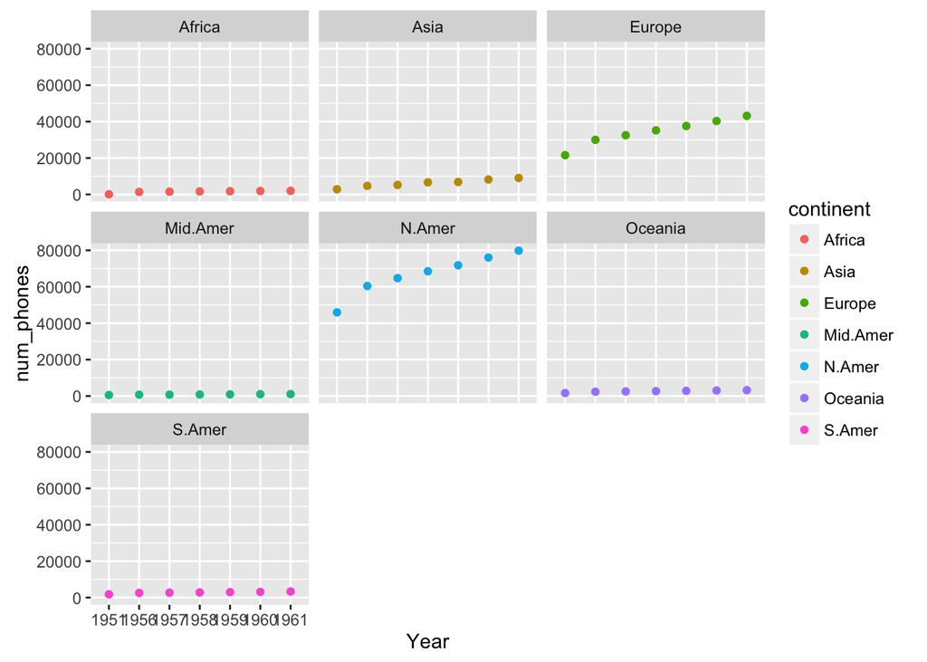

```r
WorldPhones$Year <- rownames(WorldPhones)
ds <- WorldPhones %>%
  gather(continent, num_phones, N.Amer:Mid.Amer) %>%
  arrange(Year, continent, num_phones)

ggplot(ds, aes(x = Year, y = num_phones, colour = continent)) +
  facet_wrap(~ continent)+
   geom_point()
```

You will be presenting one of these plots to the group.

## Flights

1. The plot below displays the relationship between the mean arrival delay and the mean distance travelled by every plane in the data set. It also shows the total number of flights made by each plane by the size of the plotted circle. Please form a single chain that will create this plot, starting with the raw data set. You will also want to exclude the edge cases from your analysis, so focus on the planes that have logged more than 20 flights and flown an average distance of less than 2000 miles.

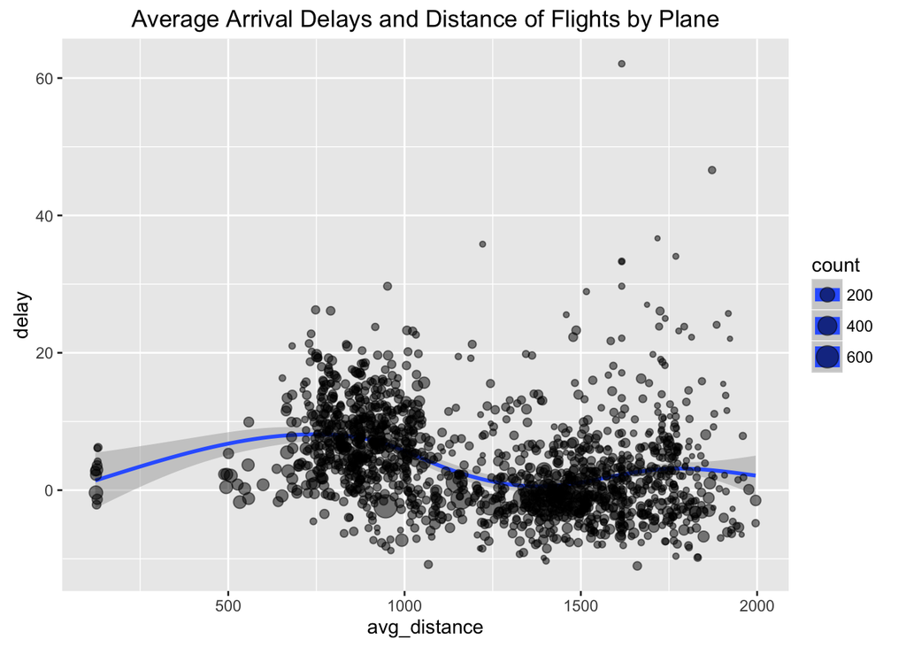

```r
flights %>%
  group_by(tailnum) %>%
  summarize(count = n(), avg_distance = mean(distance),
            delay = mean(arr_delay)) %>%
  filter(count > 20, avg_distance < 2000) %>%
  ggplot(aes(y = delay, x = avg_distance, size = count)) +
    geom_smooth() +
    geom_point(alpha = .5) +
  ggtitle("Average Arrival Delays and Distance of Flights by Plane")
```

### code below wasn’t working so I took it out of it’s R chunk

library(pnwflights14)